# Brazilian Companies

Author

Jo Hardin

Published

```r
library(tidyverse) # ggplot, lubridate, dplyr, stringr, readr...
library(praise)
library(tidytext)
library(rvest)
```

## The Data

This week we’re exploring **Brazilian Companies**, curated from Brazil’s open **CNPJ (Cadastro Nacional da Pessoa Jurídica)** records published by the **Brazilian Ministry of Finance / Receita Federal** on the national open-data portal ([dados.gov.br](https://dados.gov.br/dados/conjuntos-dados/cadastro-nacional-da-pessoa-juridica---cnpj)).

> The CNPJ open data is a large-scale public registry of Brazilian legal entities. For this dataset, the raw company records were cleaned and enriched with lookup tables (legal nature, owner qualification, and company size), then filtered to retain firms above a share-capital threshold so the analysis focuses on meaningful variation in capital stock.
- Which **legal nature** categories concentrate the highest total and average capital stock?
- How does **company size** relate to capital stock (and how skewed is it)?
- Do specific **owner qualification** groups dominate high-capital companies?
- What patterns emerge when comparing the **top capital-stock tail** across categories (legal nature, size, qualification)?

Thank you to [Marcelo Silva](https://github.com/MarcleoSilva) for curating this week’s dataset.

```r
companies <- readr::read_csv('https://raw.githubusercontent.com/rfordatascience/tidytuesday/main/data/2026/2026-01-27/companies.csv') |>
  mutate(owner = case_when(
    owner_qualification == "Administrator / Manager" ~ "Manager",
    owner_qualification == "Attorney-in-fact / Legal Representative (Power of Attorney)" ~ "Legal Representative",
    owner_qualification == "Beneficial Owner (individual) resident or domiciled in Brazil" ~ "Individual Owner",
    owner_qualification == "Director / Officer" ~ "Director",
    owner_qualification == "Entrepreneur / Business Owner" ~ "Entrepreneur",
    owner_qualification == "Executor / Estate Administrator" ~ "Executor",
    owner_qualification == "Intervenor / Court-appointed Administrator" ~ "Intervenor",
    owner_qualification == "Judicial Administrator (Court-appointed)" ~ "Judicial",
    owner_qualification == "Liquidator" ~ "Liquidator",
    owner_qualification == "Managing Partner / Partner-Administrator" ~ "Partner",
    owner_qualification == "Ostensible Partner (Managing partner in a silent partnership)" ~ "Ostensible Partner",
    owner_qualification == "President / Chair" ~ "President",
    owner_qualification == "Sole Owner of an Individual Real Estate Company" ~ "Owner"
  ))
```

# Looking at capital broken down by owner qualification

```r
companies |>
  group_by(owner_qualification) |>
  summarize(n())
```

```
# A tibble: 13 × 2
   owner_qualification                                            `n()`
   <chr>                                                          <int>
 1 Administrator / Manager                                        15236
 2 Attorney-in-fact / Legal Representative (Power of Attorney)       13
 3 Beneficial Owner (individual) resident or domiciled in Brazil    442
 4 Director / Officer                                              1634
 5 Entrepreneur / Business Owner                                  15201
 6 Executor / Estate Administrator                                   22
 7 Intervenor / Court-appointed Administrator                         1
 8 Judicial Administrator (Court-appointed)                         302
 9 Liquidator                                                        29
10 Managing Partner / Partner-Administrator                      107027
11 Ostensible Partner (Managing partner in a silent partnership)     32
12 President / Chair                                               1343
13 Sole Owner of an Individual Real Estate Company                   50
```

```r
quantile_data <- companies |>
  filter(owner_qualification != "Intervenor / Court-appointed Administrator") |>
  group_by(owner) |>
  mutate(capital_stock = log(capital_stock, 10)) |>
  summarize(q25 = quantile(capital_stock, p = 0.25),
            q50 = quantile(capital_stock, p = 0.50),
            q75 = quantile(capital_stock, p = 0.75),
            q95 = quantile(capital_stock, p = 0.95),
            q99 = quantile(capital_stock, p = 0.99)) |>
  mutate(total = q99, q99 = q99 - q95, q95 = q95 - q75, q75 = q75 - q50, q50 = q50 - q25) |>
  mutate(owner = forcats::fct_reorder(owner, total, .desc = TRUE)) |>
  select(-total) |>
  pivot_longer(cols = q25:q99, names_to = "percentile", values_to = "quantile")
```

The coxcomb plot was fun to make, but it probably would have been better as a bar plot. We don’t get any additional information when transformed into polar coordinates.

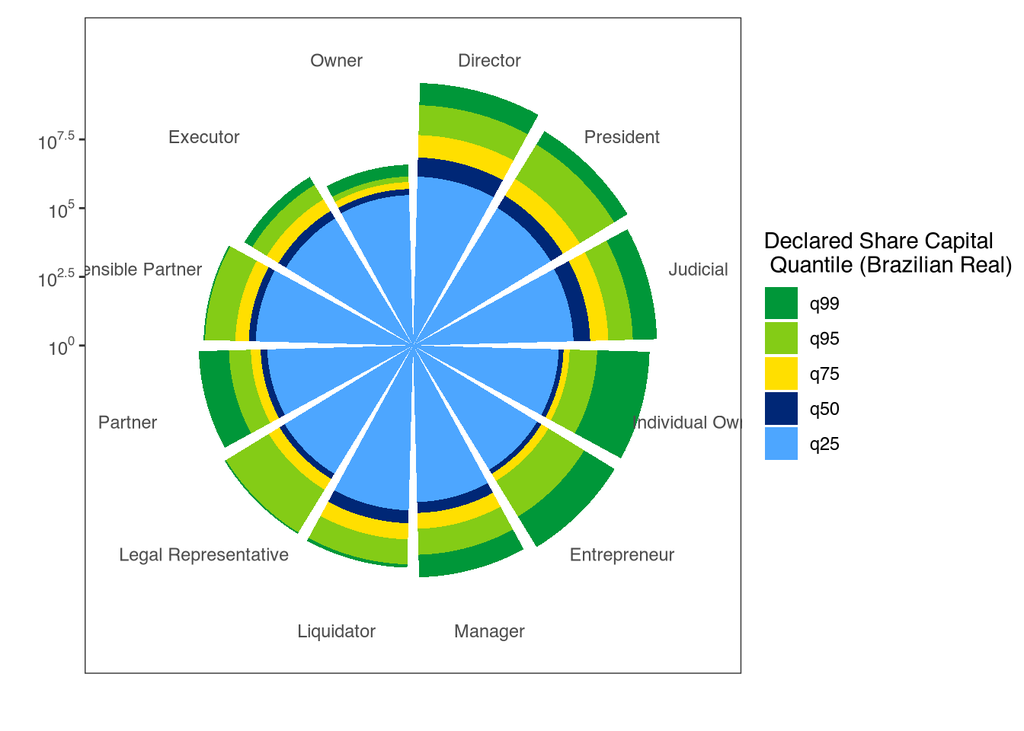

Each piece of pie represents a different owner qualification. Within the pie, the quantiles of the declared share capital is given in Brazilian reals. Owner qualification of “director” have companies worth the most, whereas “owner” companies are worth the least. The values of the declared share capital are given in log10 units.

```r
brazil_palette <- c("#009739", "#84CC16", "#FFDF00", "#002776", "#4DA6FF")


quantile_data |>
  mutate(percentile = forcats::fct_rev(percentile)) |>
  ggplot(aes(x = owner, y = quantile, fill = percentile)) +
  geom_bar(stat = "identity") +
  scale_y_continuous(labels = scales::label_math(expr = 10^.x)) +
  coord_polar() +
  scale_fill_manual(values = brazil_palette) +
  theme_test() +
  labs(x = "", y = "",
       fill = "Declared Share Capital\n Quantile (Brazilian Real)")
```

```r
praise()
```

```
[1] "You are geometric!"
```